# Neural Networks Project

## Data Description

### The Street View House Numbers (SVHN) Dataset

SVHN is a real-world image dataset for developing machine learning and object recognition algorithms with minimal requirement on data formatting but comes from a significantly harder, unsolved, real world problem (recognizing digits and numbers in natural scene images). SVHN is obtained from house numbers in Google Street View images.

## Objective:

The objective of the project is to learn how to implement a simple image classification pipeline based on a deep neural network. The goals of this project are as follows:

### Steps and tasks

1. Load Dataset
2. Understand the basic Image Classification pipeline and the data-driven approach (train/predict stages)
3. Data fetching and understand the train/val/test splits.
4. Implement and apply a deep neural network classifier including (feedforward neural network, RELU, activations)
5. Implement batch normalization for training the neural network
6. Print the classification accuracy metrics

```python
#### Import Libraries

import tensorflow
from tensorflow.keras.utils import to_categorical
from tensorflow.keras.models import Sequential
from tensorflow.keras.layers import Dense
from tensorflow.keras.layers import Reshape
from tensorflow.keras.layers import Activation
from tensorflow.keras.layers import BatchNormalization
from tensorflow.keras.layers import Dropout
from tensorflow.keras import regularizers, optimizers
from sklearn.preprocessing import LabelBinarizer
from sklearn.metrics import confusion_matrix
import seaborn as sns
sns.set()

from tensorflow.keras.layers import Convolution2D
from tensorflow.keras.layers import MaxPooling2D
import h5py
import numpy as np
import pandas as pd
import matplotlib.pyplot as plt
%matplotlib inline

### Initialize the random number generator
import random
random.seed(0)

### Ignore the warnings
import warnings
warnings.filterwarnings("ignore")
```

```python
### Check tensorflow version
tensorflow.__version__
```

```
'2.1.0'
```

# 1. Load Dataset

```python
# Open the file as rand only
h5f = h5py.File('SVHN_single_grey1.h5', 'r')
```

```python
h5f.keys()
```

```
<KeysViewHDF5 ['X_test', 'X_train', 'X_val', 'y_test', 'y_train', 'y_val']>
```

```python
# Load the training, test and validation data set
X_train_original = h5f["X_train"][:]
y_train_original = h5f["y_train"][:]
X_test_original = h5f["X_test"][:]
y_test_original = h5f["y_test"][:]
X_val_original = h5f["X_val"][:]
y_val_original = h5f["y_val"][:]
# Close the file
h5f.close()
```

# 2. Understand the basic Image Classification pipeline and the data-driven approach (train/predict stages)

SVHN is obtained from house numbers in Google Street View images.

- 10 classes, 1 for each digit. Digit '1' has label 1, '9' has label 9, '0' has lable 0.
- The images come in two formats as follows.

  ```
   Format 1 : Original images with character level bounding boxes. (Full Numbers)
   Format 2 : MNIST-like 32-by-32 images centered around a single character (many of the images do contain some distractors at the sides)(Cropped Digits).
  ```

The Image classification pipeline:

- Split given data to train, validation and test datasets
- Reshape Image data from 3D to 2D (From(,32,32) to (,1024))
- Normalize features from 0-255 to 0-1 for X_train,X_val and X_test
- Do one-hot encoding for class vectors y_train, y_val and y_test
- Create the model
- Define the input layer, hidden layer, activation functions, number of nurons for each layer and hyper parameters
- Calculate the loss and accuracy of the model on training and validation sets
- Apply batch normalization to the model
- Tune the model with different hyper parameters and calculate the loss and accuracy on trainng and validation sets
- Evaluate the model on test dataset and calculate the loss and accuracy
- Try to predict scores for some of the test class

# 3. Data fetching and understand the train/val/test splits.

```python
### Print shape of the original data
print(X_train_original.shape)
print(y_train_original.shape)
print(X_test_original.shape)
print(y_test_original.shape)
print(X_val_original.shape)
print(y_val_original.shape)
```

```
(42000, 32, 32)
(42000,)
(18000, 32, 32)
(18000,)
(60000, 32, 32)
(60000,)
```

- The SVHN database contains 42,000 training images, 60,000 validation images and 18,000 testing images
- Images are represented as 3D arrays of numbers, with integers between 0 and 255.
- X_train, X_val, X_test: Array of grayscale image data with shape (num_samples, 32, 32)
- y_train, y_val, y_test: Array of digit labels (integers in range 0-9) with shape (num_samples,).
- X_train,X_val and X_test contain greyscale RGB codes (from 0 to 255) while y_train and y_test contains labels from 0 to 9 which represents which number they actually are.

```python
### Copying original data set for processing
X_train = X_train_original
X_val = X_val_original
X_test = X_test_original
y_train = y_train_original
y_val = y_val_original
y_test = y_test_original
```

```python
### Print shape of the copied data
print(X_train.shape)
print(y_train.shape)
print(X_test.shape)
print(y_test.shape)
print(X_val.shape)
print(y_val.shape)
```

```
(42000, 32, 32)
(42000,)
(18000, 32, 32)
(18000,)
(60000, 32, 32)
(60000,)
```

```
Label: 7
```

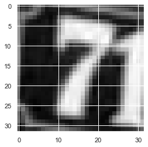

```python
### Print shape and some values of label
print("Label: {}".format(y_train[5000]))
plt.imshow(X_train[5000], cmap='gray')
```

```python
### Reshape features from 3D to 2D by converting 32*32 to 1024
X_train = X_train.reshape(42000, 1024)
print(X_train.shape)
X_val = X_val.reshape(60000, 1024)
print(X_val.shape)
X_test = X_test.reshape(18000, 1024)
print(X_test.shape)
```

```
(42000, 1024)
(60000, 1024)
(18000, 1024)
```

```python
### Normalize features from 0-255 to 0-1
print(X_train.max())
print(X_train.min())

X_train = X_train / 255.0
X_val = X_val / 255.0
X_test = X_test / 255.0

print(X_train.max())
print(X_train.min())
```

```
254.9745
0.0
0.9999
0.0
```

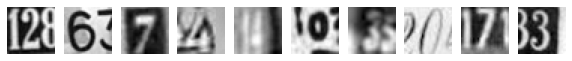

```
label for each of the above image: [2 6 7 4 4 0 3 0 7 3]
```

```python
# visualizing the first 10 images in the train dataset and their labels
%matplotlib inline
import matplotlib.pyplot as plt
plt.figure(figsize=(10, 1))
for i in range(10):
    plt.subplot(1, 10, i+1)
    plt.imshow(X_train[i].reshape(32, 32), cmap="gray")
    plt.axis('off')
plt.show()
print('label for each of the above image: %s' % (y_train[0:10]))
```

# 4. Implement and apply a deep neural network classifier including (feedforward neural network, RELU, activations)

Here I am trying to apply a neural network clasifier for the given data using two approaches. First one is build the model from scratch without using tensorflow and the second one is build the model with tensorflow and keras.

## Neural Network from scratch without Tensorflow

#### First we will try to build a model for this dataset without tensorflow by defining different layers and activation functions. Below are the steps we are going to build in this scenario.

- Fully Connected Layer (Linear Layer)
- Rectified Linear Activation Layer (ReLU)
- Defining the softmax function
- Defining the Cross Entropy Loss
- Loading the MNIST dataset
- NN class that enables the forward prop and backward propagation
- Defining the update function (SGD with momentum)
- Defining a function which gives us the minibatches
- The traning loop
- Checking the accuracy of the model
- Model Invoker which will execute all the above what we defined

```python
### Fully Connected Layer (Linear Layer)
class Linear():
    def __init__(self, in_size, out_size):
        self.W = np.random.randn(in_size, out_size) * 0.01
        self.b = np.zeros((1, out_size))
        self.params = [self.W, self.b]
        self.gradW = None
        self.gradB = None
        self.gradInput = None

    def forward(self, X):
        self.X = X
        self.output = np.dot(X, self.W) + self.b
        return self.output

    def backward(self, nextgrad):
        self.gradW = np.dot(self.X.T, nextgrad)
        self.gradB = np.sum(nextgrad, axis=0)
        self.gradInput = np.dot(nextgrad, self.W.T)
        return self.gradInput, [self.gradW, self.gradB]
```

```python
### Rectified Linear Activation Layer (ReLU)
class ReLU():
    def __init__(self):
        self.params = []
        self.gradInput = None

    def forward(self, X):
        self.output = np.maximum(X, 0)
        return self.output

    def backward(self, nextgrad):
        self.gradInput = nextgrad.copy()
        self.gradInput[self.output <=0] = 0
        return self.gradInput, []
```

```python
### Defining the softmax function
def softmax(x):
    exp_x = np.exp(x - np.max(x, axis=1, keepdims=True))
    return exp_x / np.sum(exp_x, axis=1, keepdims=True)
```

```python
### Defining the Cross Entropy Loss
class CrossEntropy:
    def forward(self, X, y):
        self.m = y.shape[0]
        self.p = softmax(X)
        cross_entropy = -np.log(self.p[range(self.m), y])
        loss = np.sum(cross_entropy) / self.m      # which involves taking a sum across the losses for all the examples in the batch
        return loss

    def backward(self, X, y):
        y_idx = y.argmax()
        grad = softmax(X)
        grad[range(self.m), y] -= 1
        grad /= self.m
        return grad
```

```python
### NN class that enables the forward prop and backward propagation
class NN():
    def __init__(self, lossfunc=CrossEntropy()):
        self.params = []
        self.layers = []
        self.loss_func = lossfunc
        self.grads = []

    def add_layer(self, layer):
        self.layers.append(layer)
        self.params.append(layer.params)

    def forward(self, X):
        for layer in self.layers:
            X = layer.forward(X)
        return X

    def backward(self, nextgrad):
        self.clear_grad_param()
        for layer in reversed(self.layers):
            nextgrad, grad = layer.backward(nextgrad)
            self.grads.append(grad)
        return self.grads

    def train_step(self, X, y):
        out = self.forward(X)
        loss = self.loss_func.forward(out,y)
        nextgrad = self.loss_func.backward(out,y)
        grads = self.backward(nextgrad)
        return loss, grads

    def predict(self, X):
        X = self.forward(X)
        return np.argmax(X, axis=1)

    def predict_scores(self, X):
        X = self.forward(X)
        return X

    def clear_grad_param(self):
        self.grads = []
```

```python
### Defining the update function (SGD with momentum)
def update_params(velocity, params, grads, learning_rate=0.01, mu=0.9):
    for v, p, g, in zip(velocity, params, reversed(grads)):
        for i in range(len(g)):
            v[i] = mu * v[i] + learning_rate * g[i]
            p[i] -= v[i]
```

```python
# Defining a function which gives us the minibatches
def minibatch(X, y, minibatch_size):
#     print("X.shape = ", X.shape)
#     print("y.shape = ", y.shape)
    n = X.shape[0]
    minibatches = []
    permutation = np.random.permutation(X.shape[0])
    X = X[permutation]
    y = y[permutation]

    for i in range(0, n , minibatch_size):
        X_batch = X[i:i + minibatch_size, :]
        y_batch = y[i:i + minibatch_size, ]
        minibatches.append((X_batch, y_batch))

    return minibatches
```

```python
### The traning loop
mean_train_loss=0
train_acc=0
mean_val_loss=0
val_acc=0
def train(net, X_train, y_train, minibatch_size, epoch, learning_rate, mu=0.9, X_val=None, y_val=None):
    val_loss_epoch = []
    minibatches = minibatch(X_train, y_train, minibatch_size)
    minibatches_val = minibatch(X_val, y_val, minibatch_size)
    print("Train on ",X_train.shape[0]," samples, validate on", X_val.shape[0]," samples")

    for i in range(epoch):
        print("Epoch %d/%d" %(i+1,epoch))
        loss_batch = []
        val_loss_batch = []
        velocity = []
        for param_layer in net.params:
            p = [np.zeros_like(param) for param in list(param_layer)]
            velocity.append(p)

        # iterate over mini batches
        for X_mini, y_mini in minibatches:
            loss, grads = net.train_step(X_mini, y_mini)
            loss_batch.append(loss)
            update_params(velocity, net.params, grads, learning_rate=learning_rate, mu=mu)

        for X_mini_val, y_mini_val in minibatches_val:
            val_loss, _ = net.train_step(X_mini, y_mini)
            val_loss_batch.append(val_loss)

        # accuracy of model at end of epoch after all mini batch updates
        m_train = X_train.shape[0]
        m_val = X_val.shape[0]
        y_train_pred = np.array([], dtype="int64")
        y_val_pred = np.array([], dtype="int64")
        y_train1 = []
        y_vall = []
        for i in range(0, m_train, minibatch_size):
            X_tr = X_train[i:i + minibatch_size, : ]
            y_tr = y_train[i:i + minibatch_size,]
            y_train1 = np.append(y_train1, y_tr)
            y_train_pred = np.append(y_train_pred, net.predict(X_tr))

        for i in range(0, m_val, minibatch_size):
            X_va = X_val[i:i + minibatch_size, : ]
            y_va = y_val[i:i + minibatch_size,]
            y_vall = np.append(y_vall, y_va)
            y_val_pred = np.append(y_val_pred, net.predict(X_va))

        global mean_train_loss,train_acc,mean_val_loss,val_acc

        train_acc = check_accuracy(y_train1, y_train_pred)
        val_acc = check_accuracy(y_vall, y_val_pred)

        mean_train_loss = sum(loss_batch) / float(len(loss_batch))
        mean_val_loss = sum(val_loss_batch) / float(len(val_loss_batch))

        val_loss_epoch.append(mean_val_loss)
        print("Loss = {0} | Training Accuracy = {1} | Val Loss = {2} | Val Accuracy = {3}".format(mean_train_loss, train_acc, mean_val_loss, val_acc))
    return net
```

```python
### Checking the accuracy of the model
def check_accuracy(y_true, y_pred):
    return np.mean(y_pred == y_true)
```

```python
### Creating a dataframe to maintain the results of different models, optimizers and learning rates for comparison
i = 0
accuracy_results = pd.DataFrame(columns=['Method', 'Lambda', 'Learning_Rate', 'Epochs', 'Train_Accuracy', 'Val_Accuracy', 'Train_Loss', 'Val_Loss'])
accuracy_results
```

|  | Method | Lambda | Learning_Rate | Epochs | Train_Accuracy | Val_Accuracy | Train_Loss | Val_Loss |
| --- | --- | --- | --- | --- | --- | --- | --- | --- |

```python
### Model Invoker which will execute all the above what we defined

## input size
input_dim = X_train.shape[1]

## hyperparameters
iterations = 30
output_nodes = 10
batch_size = 30

## define neural net
nn = NN()
### Adding Input Layter
nn.add_layer(Linear(input_dim, 100))
### Adding ReLU Activation
nn.add_layer(ReLU())
### Adding Hidden Layer
nn.add_layer(Linear(100, 200))
### Adding ReLU Activation
nn.add_layer(ReLU())
### Adding Output Layter
nn.add_layer(Linear(200, output_nodes))

lr_array=[0.0001, 0.001, 0.01,0.1]

for lr_val in lr_array:
    nn = train(nn, X_train , y_train, minibatch_size=batch_size, epoch=iterations, \
               learning_rate=lr_val, X_val=X_val, y_val=y_val)
    i = i+1
    tempResultsDf = pd.DataFrame({'Method':['NN_Scratch'], 'Lambda':['0'], 'Learning_Rate': [lr_val], 'Epochs': [iterations], 'Train_Accuracy': [train_acc], 'Val_Accuracy': [val_acc], 'Train_Loss': [mean_train_loss], 'Val_Loss': [mean_val_loss]},index={i})
    accuracy_results= pd.concat([accuracy_results, tempResultsDf])
```

```
Train on  42000  samples, validate on 60000  samples
Loss = 2.302589126456587 | Training Accuracy = 0.10197619047619047 | Val Loss = 2.302184798382459 | Val Accuracy = 0.10001666666666667
Loss = 2.302578651773148 | Training Accuracy = 0.10192857142857142 | Val Loss = 2.302054159544564 | Val Accuracy = 0.1
Loss = 2.3025698799853975 | Training Accuracy = 0.10192857142857142 | Val Loss = 2.3019408410927946 | Val Accuracy = 0.1
Loss = 2.3025628431619842 | Training Accuracy = 0.10192857142857142 | Val Loss = 2.301841722271416 | Val Accuracy = 0.1
Loss = 2.302557118333376 | Training Accuracy = 0.10192857142857142 | Val Loss = 2.3017560557618504 | Val Accuracy = 0.1
Loss = 2.3025523959867567 | Training Accuracy = 0.10192857142857142 | Val Loss = 2.3016831907040487 | Val Accuracy = 0.1
Loss = 2.3025482987334414 | Training Accuracy = 0.10192857142857142 | Val Loss = 2.30162167661094 | Val Accuracy = 0.1
Loss = 2.302544624151959 | Training Accuracy = 0.10192857142857142 | Val Loss = 2.301569832792994 | Val Accuracy = 0.1
Loss = 2.302541260311277 | Training Accuracy = 0.10192857142857142 | Val Loss = 2.301524407312759 | Val Accuracy = 0.1
Loss = 2.3025380620819256 | Training Accuracy = 0.10192857142857142 | Val Loss = 2.301485764045536 | Val Accuracy = 0.1
Loss = 2.302535128625634 | Training Accuracy = 0.10192857142857142 | Val Loss = 2.3014526162678774 | Val Accuracy = 0.1
Loss = 2.3025324464107935 | Training Accuracy = 0.10192857142857142 | Val Loss = 2.3014238361869714 | Val Accuracy = 0.1
Loss = 2.3025299218472024 | Training Accuracy = 0.10192857142857142 | Val Loss = 2.301398515180153 | Val Accuracy = 0.1
Loss = 2.302527495039452 | Training Accuracy = 0.10192857142857142 | Val Loss = 2.3013760747380934 | Val Accuracy = 0.1
Loss = 2.3025251181385915 | Training Accuracy = 0.10192857142857142 | Val Loss = 2.3013578674226904 | Val Accuracy = 0.1
Loss = 2.302522729222177 | Training Accuracy = 0.10192857142857142 | Val Loss = 2.301341857012125 | Val Accuracy = 0.1
Loss = 2.3025203632988545 | Training Accuracy = 0.10192857142857142 | Val Loss = 2.301326884460751 | Val Accuracy = 0.1
Loss = 2.3025180680173234 | Training Accuracy = 0.10192857142857142 | Val Loss = 2.3013139881182365 | Val Accuracy = 0.1
Loss = 2.302515746324487 | Training Accuracy = 0.10192857142857142 | Val Loss = 2.3013026582311036 | Val Accuracy = 0.1
Loss = 2.3025134315526854 | Training Accuracy = 0.10192857142857142 | Val Loss = 2.3012932696742046 | Val Accuracy = 0.1
Loss = 2.302511088036492 | Training Accuracy = 0.10192857142857142 | Val Loss = 2.301285343056711 | Val Accuracy = 0.1
Loss = 2.3025086742076377 | Training Accuracy = 0.10192857142857142 | Val Loss = 2.301278691671142 | Val Accuracy = 0.1
Loss = 2.3025061689416204 | Training Accuracy = 0.10192857142857142 | Val Loss = 2.3012715780084005 | Val Accuracy = 0.1
Loss = 2.302503661649976 | Training Accuracy = 0.10192857142857142 | Val Loss = 2.301264806610643 | Val Accuracy = 0.1
Loss = 2.3025012479028875 | Training Accuracy = 0.10192857142857142 | Val Loss = 2.3012574996901076 | Val Accuracy = 0.1
Loss = 2.302498843065493 | Training Accuracy = 0.10192857142857142 | Val Loss = 2.301250179196865 | Val Accuracy = 0.1
Loss = 2.302496397447656 | Training Accuracy = 0.10192857142857142 | Val Loss = 2.301243409590238 | Val Accuracy = 0.1
Loss = 2.3024938944902575 | Training Accuracy = 0.10192857142857142 | Val Loss = 2.3012370772376 | Val Accuracy = 0.1
Loss = 2.3024913338899737 | Training Accuracy = 0.10192857142857142 | Val Loss = 2.3012311235221605 | Val Accuracy = 0.1
Loss = 2.302488707417783 | Training Accuracy = 0.10192857142857142 | Val Loss = 2.301225155454625 | Val Accuracy = 0.1
Train on  42000  samples, validate on 60000  samples
Loss = 2.3025922570700406 | Training Accuracy = 0.10192857142857142 | Val Loss = 2.304551307917715 | Val Accuracy = 0.1
Loss = 2.3025620813092793 | Training Accuracy = 0.10192857142857142 | Val Loss = 2.3047750549689625 | Val Accuracy = 0.1
Loss = 2.3025220704002782 | Training Accuracy = 0.10192857142857142 | Val Loss = 2.3047959554023945 | Val Accuracy = 0.1
Loss = 2.3024671464589797 | Training Accuracy = 0.10192857142857142 | Val Loss = 2.3047691347974246 | Val Accuracy = 0.1
Loss = 2.302394695646051 | Training Accuracy = 0.10192857142857142 | Val Loss = 2.304713071770896 | Val Accuracy = 0.1
Loss = 2.3022930795292864 | Training Accuracy = 0.10192857142857142 | Val Loss = 2.304632686717337 | Val Accuracy = 0.1
Loss = 2.302144929206789 | Training Accuracy = 0.10192857142857142 | Val Loss = 2.3045315263198316 | Val Accuracy = 0.1
Loss = 2.30191750154037 | Training Accuracy = 0.10192857142857142 | Val Loss = 2.304368827454613 | Val Accuracy = 0.1
```

[output cut: 69 more lines]

```
Loss = 2.310039812622493 | Training Accuracy = 0.0999047619047619 | Val Loss = 2.325034199962805 | Val Accuracy = 0.1
Loss = 2.310039812622493 | Training Accuracy = 0.0999047619047619 | Val Loss = 2.325034199962805 | Val Accuracy = 0.1
Loss = 2.310039812622493 | Training Accuracy = 0.0999047619047619 | Val Loss = 2.325034199962805 | Val Accuracy = 0.1
Loss = 2.310039812622493 | Training Accuracy = 0.0999047619047619 | Val Loss = 2.325034199962805 | Val Accuracy = 0.1
Loss = 2.310039812622493 | Training Accuracy = 0.0999047619047619 | Val Loss = 2.325034199962805 | Val Accuracy = 0.1
Loss = 2.310039812622493 | Training Accuracy = 0.0999047619047619 | Val Loss = 2.325034199962805 | Val Accuracy = 0.1
Loss = 2.310039812622493 | Training Accuracy = 0.0999047619047619 | Val Loss = 2.325034199962805 | Val Accuracy = 0.1
Loss = 2.310039812622493 | Training Accuracy = 0.0999047619047619 | Val Loss = 2.325034199962805 | Val Accuracy = 0.1
Loss = 2.310039812622493 | Training Accuracy = 0.0999047619047619 | Val Loss = 2.325034199962805 | Val Accuracy = 0.1
Loss = 2.310039812622493 | Training Accuracy = 0.0999047619047619 | Val Loss = 2.325034199962805 | Val Accuracy = 0.1
Loss = 2.310039812622493 | Training Accuracy = 0.0999047619047619 | Val Loss = 2.325034199962805 | Val Accuracy = 0.1
Loss = 2.310039812622493 | Training Accuracy = 0.0999047619047619 | Val Loss = 2.325034199962805 | Val Accuracy = 0.1
Loss = 2.310039812622493 | Training Accuracy = 0.0999047619047619 | Val Loss = 2.325034199962805 | Val Accuracy = 0.1
Loss = 2.310039812622493 | Training Accuracy = 0.0999047619047619 | Val Loss = 2.325034199962805 | Val Accuracy = 0.1
Loss = 2.310039812622493 | Training Accuracy = 0.0999047619047619 | Val Loss = 2.325034199962805 | Val Accuracy = 0.1
```

```python
accuracy_results
```

|  | Method | Lambda | Learning_Rate | Epochs | Train_Accuracy | Val_Accuracy | Train_Loss | Val_Loss |
| --- | --- | --- | --- | --- | --- | --- | --- | --- |
| 1 | NN_Scratch | 0 | 0.0001 | 30 | 0.101929 | 0.100000 | 2.302489 | 2.301225 |
| 2 | NN_Scratch | 0 | 0.0010 | 30 | 0.664952 | 0.663650 | 1.105333 | 1.183426 |
| 3 | NN_Scratch | 0 | 0.0100 | 30 | 0.812548 | 0.800783 | 0.566225 | 0.990282 |
| 4 | NN_Scratch | 0 | 0.1000 | 30 | 0.099905 | 0.100000 | 2.310040 | 2.325034 |

#### Observation

- We have trained the same scratch model with different Learning Rates.
- We can observe that the model trained with Learning Rate = 0.01 is giving highest Validation Accuracy of 0.800783.

## Neural Network with Deep Learining libraries Tensorflow and Keras

```python
X_train = X_train_original
X_val = X_val_original
X_test = X_test_original
y_train = y_train_original
y_val = y_val_original
y_test = y_test_original
```

### One-hot encode the class vector

- convert class vectors (integers) to binary class matrix
- convert y_train and y_test
- number of classes: 10
- we are doing this to use categorical_crossentropy as loss

```python
print(y_train[2350])
y_train = to_categorical(y_train, num_classes=10)
y_val = to_categorical(y_val, num_classes=10)
y_test = to_categorical(y_test, num_classes=10)
print(y_train[2350])
```

```
4
[0. 0. 0. 0. 1. 0. 0. 0. 0. 0.]
```

```python
print(X_train.shape)
print(y_train.shape)
print(X_test.shape)
print(y_test.shape)
print(X_val.shape)
print(y_val.shape)
```

```
(42000, 32, 32)
(42000, 10)
(18000, 32, 32)
(18000, 10)
(60000, 32, 32)
(60000, 10)
```

# 5. Implement batch normalization for training the neural network

### Define the model

- The Sequential model is a linear stack of layers.
- The model needs to know what input shape it should expect. For this reason, the first layer in a Sequential model (and only the first, because following layers can do automatic shape inference) needs to receive information about its input shape.
- We can also simply add layers via the .add() method
- First we will try with SGD optimizer and next we will try with Adam optimizer
- We will tune the model with different learning rates and the lambda(regularizatin) values
- Identify the best model with good Validation Accuracy
- We will use the final model to calculate the accuracy in Test dataset
- We will try to predict and compare some of the test values.

```python
# Initialize Sequential model
model = tensorflow.keras.models.Sequential()

# Reshape data from 3D to 2D -> 32x32 to 1024
model.add(tensorflow.keras.layers.Reshape((1024,),input_shape=(32,32,)))

# Normalize the data
model.add(tensorflow.keras.layers.BatchNormalization())
```

```python
# Initialize Sequential model
model = tensorflow.keras.models.Sequential()

# Reshape data from 3D to 2D -> 32x32 to 1024
model.add(tensorflow.keras.layers.Reshape((1024,),input_shape=(32,32,)))

# Normalize the data
model.add(tensorflow.keras.layers.BatchNormalization())
```

#### Apply ReLU and Dropout

```python
### Adding Hidden Layer 1
model.add(Dense(512, activation='relu', name='Layer_1'))
#Adding BatchNormalization Layer
model.add(BatchNormalization())
### Adding Hidden Layer 2
model.add(Dense(256, activation='relu', name='Layer_2'))
#Adding BatchNormalization Layer
model.add(BatchNormalization())
### Adding Hidden Layer 3
model.add(Dense(128, activation='relu', name='Layer_3'))
#Adding BatchNormalization Layer
model.add(BatchNormalization())
#Adding Dropout layer
model.add(Dropout(0.5))
### ### Adding Hidden Layer 4
model.add(Dense(64, activation='relu', name='Layer_4'))
#Adding BatchNormalization Layer
model.add(BatchNormalization())
### Adding Hidden Layer 5
model.add(Dense(32, activation='relu', name='Layer_5'))
#Adding BatchNormalization Layer
model.add(BatchNormalization())
#Adding Dropout layer
model.add(Dropout(0.5))
```

```python
# Add Output layer
model.add(tensorflow.keras.layers.Dense(10, activation='softmax', name='Output'))
```

#### Compile the model

- Here we configure the model for training
- We will specify an optimizer, loss function and a metrics

```python
model.compile(optimizer='sgd', loss='categorical_crossentropy', metrics=['accuracy'])
```

#### Summarize the model

- model.summary() prints a summary representation of your model. For layers with multiple outputs, multiple is displayed instead of each individual output shape due to size limitations.

```python
model.summary()
```

```
Model: "sequential_1"
_________________________________________________________________
Layer (type)                 Output Shape              Param #
=================================================================
reshape_1 (Reshape)          (None, 1024)              0
_________________________________________________________________
batch_normalization_1 (Batch (None, 1024)              4096
_________________________________________________________________
Layer_1 (Dense)              (None, 512)               524800
_________________________________________________________________
batch_normalization_2 (Batch (None, 512)               2048
_________________________________________________________________
Layer_2 (Dense)              (None, 256)               131328
_________________________________________________________________
batch_normalization_3 (Batch (None, 256)               1024
_________________________________________________________________
Layer_3 (Dense)              (None, 128)               32896
_________________________________________________________________
batch_normalization_4 (Batch (None, 128)               512
_________________________________________________________________
dropout (Dropout)            (None, 128)               0
_________________________________________________________________
Layer_4 (Dense)              (None, 64)                8256
_________________________________________________________________
batch_normalization_5 (Batch (None, 64)                256
_________________________________________________________________
Layer_5 (Dense)              (None, 32)                2080
_________________________________________________________________
batch_normalization_6 (Batch (None, 32)                128
_________________________________________________________________
dropout_1 (Dropout)          (None, 32)                0
_________________________________________________________________
Output (Dense)               (None, 10)                330
=================================================================
Total params: 707,754
Trainable params: 703,722
Non-trainable params: 4,032
_________________________________________________________________
```

#### Fit the model

- .fit() trains the model for a fixed number of epochs (iterations on a dataset)
- An epoch is an iteration over the entire x and y data provided
- batch_size is the number of samples per gradient update
- validation_data is the data on which to evaluate the loss and any model metrics at the end of each epoch

```python
history = model.fit(X_train, y_train, validation_data=(X_val, y_val), epochs=30, batch_size = 30)
```

```
Train on 42000 samples, validate on 60000 samples
```

```python
# Evaluate train and validation accuracies and losses

train_acc = history.history['accuracy']
val_acc = history.history['val_accuracy']

train_loss = history.history['loss']
val_loss = history.history['val_loss']
```

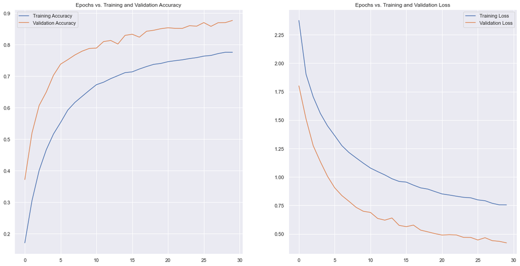

```python
# Visualize epochs vs. train and validation accuracies and losses

plt.figure(figsize=(20, 10))

plt.subplot(1, 2, 1)
plt.plot(train_acc, label='Training Accuracy')
plt.plot(val_acc, label='Validation Accuracy')
plt.legend()
plt.title('Epochs vs. Training and Validation Accuracy')

plt.subplot(1, 2, 2)
plt.plot(train_loss, label='Training Loss')
plt.plot(val_loss, label='Validation Loss')
plt.legend()
plt.title('Epochs vs. Training and Validation Loss')

plt.show()
```

### Tuning the model with different optimizers, learning rates and lambda values to identify the case with highest validation accuracy

#### Tuning SGD Optimizer with different learning rates and lambda values

```python
lambda_array=[0.0001,0.001,0.01,0.1]
### This loop is to create different sequential models with different lambda(regularization) values
for lambda_val in lambda_array:
    # Initialize Sequential model
    model = Sequential()

    ### Input Layer
    # Reshape data from 3D to 2D -> 32x32 to 1024
    model.add(Reshape((1024,),input_shape=(32,32,)))

    #Adding BatchNormalization Layer
    model.add(BatchNormalization())
    ### Adding Hidden Layer 1
    model.add(Dense(512, activation='relu', name='Layer_1'))
    #Adding BatchNormalization Layer
    model.add(BatchNormalization())
    ### Adding Hidden Layer 2
    model.add(Dense(256, activation='relu', name='Layer_2'))
    #Adding BatchNormalization Layer
    model.add(BatchNormalization())
    ### Adding Hidden Layer 3
    model.add(Dense(128, activation='relu', name='Layer_3'))
    #Adding BatchNormalization Layer
    model.add(BatchNormalization())
    #Adding Dropout layer
    model.add(Dropout(0.5))
    ### ### Adding Hidden Layer 4
    model.add(Dense(64, activation='relu', name='Layer_4'))
    #Adding BatchNormalization Layer
    model.add(BatchNormalization())
    ### Adding Hidden Layer 5
    model.add(Dense(32, activation='relu', name='Layer_5'))
    #Adding BatchNormalization Layer
    model.add(BatchNormalization())
    #Adding Dropout layer
    model.add(Dropout(0.5))

    #Adding Output layer
    model.add(Dense(10, activation='softmax', kernel_regularizer=regularizers.l2(lambda_val), name='Output'))

    lr_array=[0.0001,0.001,0.01,0.1]
    ### This loop is for the execution of same model with different learning rates
    for lr_val in lr_array:
        #Setting the learning rate  and decay in sgd
        sgd = optimizers.SGD(lr = lr_val)
        model.compile(optimizer=sgd, loss='categorical_crossentropy', metrics=['accuracy'])
        model.fit(X_train, y_train, validation_data=(X_val, y_val), epochs=30, batch_size = 30, verbose = 0)
        train_results = model.evaluate(X_train, y_train)
        val_results = model.evaluate(X_val, y_val)

        #Store the accuracy results for each model in a dataframe for final comparison
        i = i+1
        tempResultsDf = pd.DataFrame({'Method':['NN_SGD'], 'Lambda': [lambda_val], 'Learning_Rate': [lr_val], 'Epochs': [30], 'Train_Accuracy': [train_results[1]], 'Val_Accuracy': [val_results[1]], 'Train_Loss': [train_results[0]], 'Val_Loss': [val_results[0]]},index={i})
        accuracy_results= pd.concat([accuracy_results, tempResultsDf])
```

```python
accuracy_results
```

|  | Method | Lambda | Learning_Rate | Epochs | Train_Accuracy | Val_Accuracy | Train_Loss | Val_Loss |
| --- | --- | --- | --- | --- | --- | --- | --- | --- |
| 1 | NN_Scratch | 0 | 0.0001 | 30 | 0.101929 | 0.100000 | 2.302489 | 2.301225 |
| 2 | NN_Scratch | 0 | 0.0010 | 30 | 0.664952 | 0.663650 | 1.105333 | 1.183426 |
| 3 | NN_Scratch | 0 | 0.0100 | 30 | 0.812548 | 0.800783 | 0.566225 | 0.990282 |
| 4 | NN_Scratch | 0 | 0.1000 | 30 | 0.099905 | 0.100000 | 2.310040 | 2.325034 |
| 5 | NN_SGD | 0.0001 | 0.0001 | 30 | 0.488762 | 0.484433 | 1.638390 | 1.644558 |
| 6 | NN_SGD | 0.0001 | 0.0010 | 30 | 0.812214 | 0.803817 | 0.659826 | 0.682878 |
| 7 | NN_SGD | 0.0001 | 0.0100 | 30 | 0.907262 | 0.891633 | 0.327430 | 0.375160 |
| 8 | NN_SGD | 0.0001 | 0.1000 | 30 | 0.930310 | 0.912167 | 0.243583 | 0.303424 |
| 9 | NN_SGD | 0.001 | 0.0001 | 30 | 0.473524 | 0.469483 | 1.677516 | 1.682458 |
| 10 | NN_SGD | 0.001 | 0.0010 | 30 | 0.815571 | 0.806417 | 0.671779 | 0.695493 |
| 11 | NN_SGD | 0.001 | 0.0100 | 30 | 0.899048 | 0.882467 | 0.356916 | 0.406895 |
| 12 | NN_SGD | 0.001 | 0.1000 | 30 | 0.926929 | 0.909483 | 0.262026 | 0.320216 |
| 13 | NN_SGD | 0.01 | 0.0001 | 30 | 0.439524 | 0.438067 | 1.806778 | 1.810354 |
| 14 | NN_SGD | 0.01 | 0.0010 | 30 | 0.802190 | 0.794100 | 0.785503 | 0.806965 |
| 15 | NN_SGD | 0.01 | 0.0100 | 30 | 0.904024 | 0.888833 | 0.372418 | 0.418415 |
| 16 | NN_SGD | 0.01 | 0.1000 | 30 | 0.916214 | 0.898567 | 0.314134 | 0.372615 |
| 17 | NN_SGD | 0.1 | 0.0001 | 30 | 0.387714 | 0.386367 | 2.145529 | 2.147435 |
| 18 | NN_SGD | 0.1 | 0.0010 | 30 | 0.728357 | 0.721583 | 1.169928 | 1.183359 |
| 19 | NN_SGD | 0.1 | 0.0100 | 30 | 0.894857 | 0.881250 | 0.476596 | 0.516820 |
| 20 | NN_SGD | 0.1 | 0.1000 | 30 | 0.919190 | 0.902283 | 0.401693 | 0.453489 |

#### Tuning Adam Optimizer with different learning rates and lambda values

```python
lambda_array=[0.0001,0.001,0.01,0.1]
### This loop is to create different sequential models with different lambda(regularization) values
for lambda_val in lambda_array:
    # Initialize Sequential model
    model = Sequential()

    ### Input Layer
    # Reshape data from 3D to 2D -> 32x32 to 1024
    model.add(Reshape((1024,),input_shape=(32,32,)))

    #Adding BatchNormalization Layer
    model.add(BatchNormalization())
    ### Adding Hidden Layer 1
    model.add(Dense(512, activation='relu', name='Layer_1'))
    #Adding BatchNormalization Layer
    model.add(BatchNormalization())
    ### Adding Hidden Layer 2
    model.add(Dense(256, activation='relu', name='Layer_2'))
    #Adding BatchNormalization Layer
    model.add(BatchNormalization())
    ### Adding Hidden Layer 3
    model.add(Dense(128, activation='relu', name='Layer_3'))
    #Adding BatchNormalization Layer
    model.add(BatchNormalization())
    #Adding Dropout layer
    model.add(Dropout(0.5))
    ### ### Adding Hidden Layer 4
    model.add(Dense(64, activation='relu', name='Layer_4'))
    #Adding BatchNormalization Layer
    model.add(BatchNormalization())
    ### Adding Hidden Layer 5
    model.add(Dense(32, activation='relu', name='Layer_5'))
    #Adding BatchNormalization Layer
    model.add(BatchNormalization())
    #Adding Dropout layer
    model.add(Dropout(0.5))

    #Adding Output layer
    model.add(Dense(10, activation='softmax', kernel_regularizer=regularizers.l2(lambda_val), name='Output'))

    lr_array=[0.0001,0.001,0.01,0.1]
    ### This loop is for the execution of same model with different learning rates
    for lr_val in lr_array:
        #Setting the learning rate  and decay in sgd
        adam = optimizers.Adam(lr = lr_val)
        model.compile(optimizer=adam, loss='categorical_crossentropy', metrics=['accuracy'])
        model.fit(X_train, y_train, validation_data=(X_val, y_val), epochs=30, batch_size = 30, verbose = 0)
        train_results = model.evaluate(X_train, y_train)
        val_results = model.evaluate(X_val, y_val)

        #Store the accuracy results for each model in a dataframe for final comparison
        i = i+1
        tempResultsDf = pd.DataFrame({'Method':['NN_Adam'], 'Lambda': [lambda_val], 'Learning_Rate': [lr_val], 'Epochs': [30], 'Train_Accuracy': [train_results[1]], 'Val_Accuracy': [val_results[1]], 'Train_Loss': [train_results[0]], 'Val_Loss': [val_results[0]]},index={i})
        accuracy_results= pd.concat([accuracy_results, tempResultsDf])
```

```python
accuracy_results
```

|  | Method | Lambda | Learning_Rate | Epochs | Train_Accuracy | Val_Accuracy | Train_Loss | Val_Loss |
| --- | --- | --- | --- | --- | --- | --- | --- | --- |
| 1 | NN_Scratch | 0 | 0.0001 | 30 | 0.101929 | 0.100000 | 2.302489 | 2.301225 |
| 2 | NN_Scratch | 0 | 0.0010 | 30 | 0.664952 | 0.663650 | 1.105333 | 1.183426 |
| 3 | NN_Scratch | 0 | 0.0100 | 30 | 0.812548 | 0.800783 | 0.566225 | 0.990282 |
| 4 | NN_Scratch | 0 | 0.1000 | 30 | 0.099905 | 0.100000 | 2.310040 | 2.325034 |
| 5 | NN_SGD | 0.0001 | 0.0001 | 30 | 0.488762 | 0.484433 | 1.638390 | 1.644558 |
| 6 | NN_SGD | 0.0001 | 0.0010 | 30 | 0.812214 | 0.803817 | 0.659826 | 0.682878 |
| 7 | NN_SGD | 0.0001 | 0.0100 | 30 | 0.907262 | 0.891633 | 0.327430 | 0.375160 |
| 8 | NN_SGD | 0.0001 | 0.1000 | 30 | 0.930310 | 0.912167 | 0.243583 | 0.303424 |
| 9 | NN_SGD | 0.001 | 0.0001 | 30 | 0.473524 | 0.469483 | 1.677516 | 1.682458 |
| 10 | NN_SGD | 0.001 | 0.0010 | 30 | 0.815571 | 0.806417 | 0.671779 | 0.695493 |
| 11 | NN_SGD | 0.001 | 0.0100 | 30 | 0.899048 | 0.882467 | 0.356916 | 0.406895 |
| 12 | NN_SGD | 0.001 | 0.1000 | 30 | 0.926929 | 0.909483 | 0.262026 | 0.320216 |
| 13 | NN_SGD | 0.01 | 0.0001 | 30 | 0.439524 | 0.438067 | 1.806778 | 1.810354 |
| 14 | NN_SGD | 0.01 | 0.0010 | 30 | 0.802190 | 0.794100 | 0.785503 | 0.806965 |
| 15 | NN_SGD | 0.01 | 0.0100 | 30 | 0.904024 | 0.888833 | 0.372418 | 0.418415 |
| 16 | NN_SGD | 0.01 | 0.1000 | 30 | 0.916214 | 0.898567 | 0.314134 | 0.372615 |
| 17 | NN_SGD | 0.1 | 0.0001 | 30 | 0.387714 | 0.386367 | 2.145529 | 2.147435 |
| 18 | NN_SGD | 0.1 | 0.0010 | 30 | 0.728357 | 0.721583 | 1.169928 | 1.183359 |
| 19 | NN_SGD | 0.1 | 0.0100 | 30 | 0.894857 | 0.881250 | 0.476596 | 0.516820 |
| 20 | NN_SGD | 0.1 | 0.1000 | 30 | 0.919190 | 0.902283 | 0.401693 | 0.453489 |
| 21 | NN_Adam | 0.0001 | 0.0001 | 30 | 0.887786 | 0.873950 | 0.387618 | 0.429659 |
| 22 | NN_Adam | 0.0001 | 0.0010 | 30 | 0.919548 | 0.904133 | 0.280391 | 0.329887 |
| 23 | NN_Adam | 0.0001 | 0.0100 | 30 | 0.916595 | 0.903150 | 0.290848 | 0.336341 |
| 24 | NN_Adam | 0.0001 | 0.1000 | 30 | 0.847690 | 0.839783 | 2278.731921 | 2323.838229 |
| 25 | NN_Adam | 0.001 | 0.0001 | 30 | 0.882548 | 0.869150 | 0.403098 | 0.445390 |
| 26 | NN_Adam | 0.001 | 0.0010 | 30 | 0.922905 | 0.907517 | 0.266200 | 0.318393 |
| 27 | NN_Adam | 0.001 | 0.0100 | 30 | 0.906143 | 0.893083 | 0.330279 | 0.372889 |
| 28 | NN_Adam | 0.001 | 0.1000 | 30 | 0.798262 | 0.793617 | 9.615521 | 82.763410 |
| 29 | NN_Adam | 0.01 | 0.0001 | 30 | 0.889333 | 0.875050 | 0.431669 | 0.472938 |
| 30 | NN_Adam | 0.01 | 0.0010 | 30 | 0.916119 | 0.901800 | 0.293335 | 0.342496 |
| 31 | NN_Adam | 0.01 | 0.0100 | 30 | 0.903857 | 0.892100 | 0.368373 | 0.409668 |
| 32 | NN_Adam | 0.01 | 0.1000 | 30 | 0.848667 | 0.842717 | 0.917692 | 1.176072 |
| 33 | NN_Adam | 0.1 | 0.0001 | 30 | 0.889405 | 0.875750 | 0.497483 | 0.535289 |
| 34 | NN_Adam | 0.1 | 0.0010 | 30 | 0.921643 | 0.906383 | 0.303561 | 0.352482 |
| 35 | NN_Adam | 0.1 | 0.0100 | 30 | 0.906571 | 0.894183 | 0.421062 | 0.462070 |
| 36 | NN_Adam | 0.1 | 0.1000 | 30 | 0.852976 | 0.847917 | 1.526464 | 1.400185 |

```python
### Find the row with max Validation Accuracy
accuracy_results[accuracy_results.Val_Accuracy == accuracy_results.Val_Accuracy.max()]
```

|  | Method | Lambda | Learning_Rate | Epochs | Train_Accuracy | Val_Accuracy | Train_Loss | Val_Loss |
| --- | --- | --- | --- | --- | --- | --- | --- | --- |
| 8 | NN_SGD | 0.0001 | 0.1 | 30 | 0.93031 | 0.912167 | 0.243583 | 0.303424 |

#### Observation

- From above table we can summarize that Neural Network model with NN_SGD optimizer with Lambda=0.0001 and Learning_Rate=0.1 has highest Validation Accuracy value of 0.912167 compare to others.
- So we can finalize that model for our evaluation and now we can build the same model once again with 100 epochs to train for much more accuracy.

### Train the finalized model with 100 epochs

```python
# Initialize Sequential model
final_model = Sequential()

### Adding Input Layer
# Reshape data from 3D to 2D -> 32x32 to 1024
final_model.add(Reshape((1024,),input_shape=(32,32,)))

#Adding BatchNormalization Layer
final_model.add(BatchNormalization())
### Adding Hidden Layer 1
final_model.add(Dense(512, activation='relu', name='Layer_1'))
#Adding BatchNormalization Layer
final_model.add(BatchNormalization())
### Adding Hidden Layer 2
final_model.add(Dense(256, activation='relu', name='Layer_2'))
#Adding BatchNormalization Layer
final_model.add(BatchNormalization())
### Adding Hidden Layer 3
final_model.add(Dense(128, activation='relu', name='Layer_3'))
#Adding BatchNormalization Layer
final_model.add(BatchNormalization())
#Adding Dropout layer
final_model.add(Dropout(0.5))
### ### Adding Hidden Layer 4
final_model.add(Dense(64, activation='relu', name='Layer_4'))
#Adding BatchNormalization Layer
final_model.add(BatchNormalization())
### Adding Hidden Layer 5
final_model.add(Dense(32, activation='relu', name='Layer_5'))
#Adding BatchNormalization Layer
final_model.add(BatchNormalization())
#Adding Dropout layer
final_model.add(Dropout(0.5))

#Output layer
final_model.add(Dense(10, activation='softmax', kernel_regularizer=regularizers.l2(0.0001), name='Output'))


#Setting the learning rate  and decay in sgd
sgd = optimizers.SGD(lr = 0.1)
final_model.compile(optimizer=sgd, loss='categorical_crossentropy', metrics=['accuracy'])
final_history = final_model.fit(X_train, y_train, validation_data=(X_val, y_val), epochs=100, batch_size = 30)
```

```
Train on 42000 samples, validate on 60000 samples
```

```python
train_results = final_model.evaluate(X_train, y_train)
val_results = final_model.evaluate(X_val, y_val)
print(train_results)
print(val_results)
```

```
[0.14108787349824395, 0.96211904]
[0.22954390777895847, 0.93628335]
```

#### Observation

- We can observe that with 100 epochs the model is giving 0.93628335 validation accuracy.

# 6. Print the classification accuracy metrics

```python
# Evaluate train and validation accuracies and losses

train_acc = final_history.history['accuracy']
val_acc = final_history.history['val_accuracy']

train_loss = final_history.history['loss']
val_loss = final_history.history['val_loss']
```

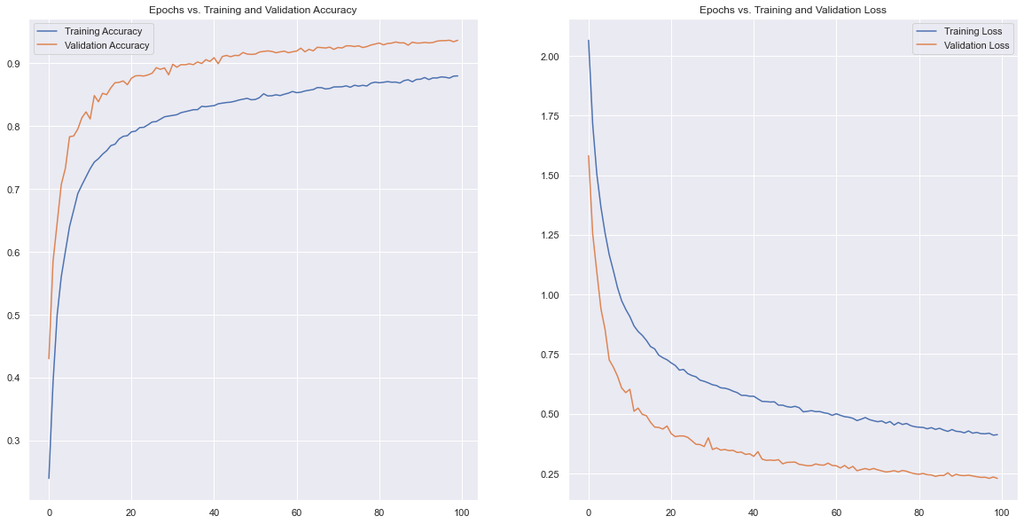

```python
# Visualize epochs vs. train and validation accuracies and losses

plt.figure(figsize=(20, 10))

plt.subplot(1, 2, 1)
plt.plot(train_acc, label='Training Accuracy')
plt.plot(val_acc, label='Validation Accuracy')
plt.legend()
plt.title('Epochs vs. Training and Validation Accuracy')

plt.subplot(1, 2, 2)
plt.plot(train_loss, label='Training Loss')
plt.plot(val_loss, label='Validation Loss')
plt.legend()
plt.title('Epochs vs. Training and Validation Loss')

plt.show()
```

#### Evaluate the model on Test Data

```python
test_results = final_model.evaluate(X_test, y_test)
print('Test Accuracy : ', test_results[1], " Test Loss : ",test_results[0])
```

```
Test Accuracy :  0.876  Test Loss :  0.4359413169556194
```

#### Observation

- We can observe that our model is giving 0.8760 accuracy with test data which is a good value.

#### Predicting the digits using NN classifier on test data

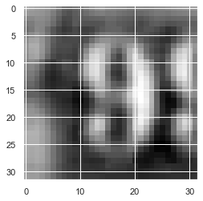

```python
#Showing the image
plt.imshow(X_test[5].reshape(32,32),cmap='gray')
```

```python
#Predicting the digits
final_model.predict_classes(X_test)[5]
```

```
9
```

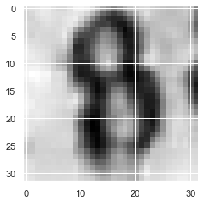

```python
#Showing the image
plt.imshow(X_test[10].reshape(32,32),cmap='gray')
```

```python
#Predicting the digits
final_model.predict_classes(X_test)[10]
```

```
8
```